# Session 1: R, RStudio & RStudio Cloud Environment

Mobina Pourmoshir

1/19/2024

# R & RStudio

[figure not shown]

- R is an open-source programming environment.
- R is used for data analysis, graphics and statistical computing.
- R language is widely used among statisticians for developing statistical software and data analysis.

# RStudio

[figure not shown]

- [RStudio](https://posit.co/) is R’s popular front-end or integrated development environment (IDE) for R and Python.
- We will use RStudio for all class related computation and analysis.
- RStudio provides syntax highlighting, code completion and smart indentation.
- Some of RStudios features includes
  - plot history, zooming, and flexible image and PDF export;
  - integrated R help and documentation;
  - generating word or pdf file output;
  - searchable command history.

# R and RStudio Interface

[figure not shown]

# RStudio Cloud

- We can implement R programs without installing R (and RStudio) locally!
- [RStudio Cloud](https://rstudio.cloud/) lets you do, share and learn statistics and data science online for free!

[figure not shown]

# Install RStudio Cloud

- Step 1: In the RStudio website https://rstudio.com/, choose **Products > posit cloud** as shown below.
- Step 2: Click **GET STARTED FOR FREE**.
- Step 3: Choose the **free** plan, and click Sign Up. Use your Marquette email address, or signup with GitHub if you use it often.
- Step 4: Once you login, you should be able to see RStudio Cloud as shown below!

[figure not shown]

# New Projects

- In RStudio Cloud, click **New Project**, then you are all set!

[figure not shown]

# First R Code in RStudio Cloud

- Give your project a nice name (click Untitled Project), math-4931 for example.

[figure not shown]

# Install R and RStudio Locally to Your Computer

### Install R – Step 1

- Go to https://cloud.r-project.org
- Click Download R for [your operating system]

[figure not shown]

# Install R and RStudio Locally to Your Computer

### Install R – Step 2

- For a Mac user, you should see the page as below. You are recommended to download and install the latest version of R (now R 4.1.2), if your OS version allows to do so. Otherwise, choose a previous version, R-3.6.3.

[figure not shown]

[figure not shown]

# Install RStudio – Step 1

- In the [RStudio website](https://www.rstudio.com/), please choose **Products > RStudio** as shown below.

[figure not shown]

# Install RStudio – Step 2

-Choose **RStudio Desktop** and click **DOWNLOAD RSTUDIO DESKTOP** for the *free* version.

[figure not shown]

# Install RStudio – Step 3

- Click **DOWNLOAD RSTUDIO FOR [YOUR SYSTEM]**. Then follow standard installation steps, you should get the software soon.
- Be careful that R should be installed successfully in your computer before you download and install RStudio.

[figure not shown]

- First R code:

```r
"Hello World!"
```

```
## [1] "Hello World!"
```

```r
7 + 4 # addition
```

```
## [1] 11
```

# Working in RStudio/RStudio Cloud

### RStudio Panes

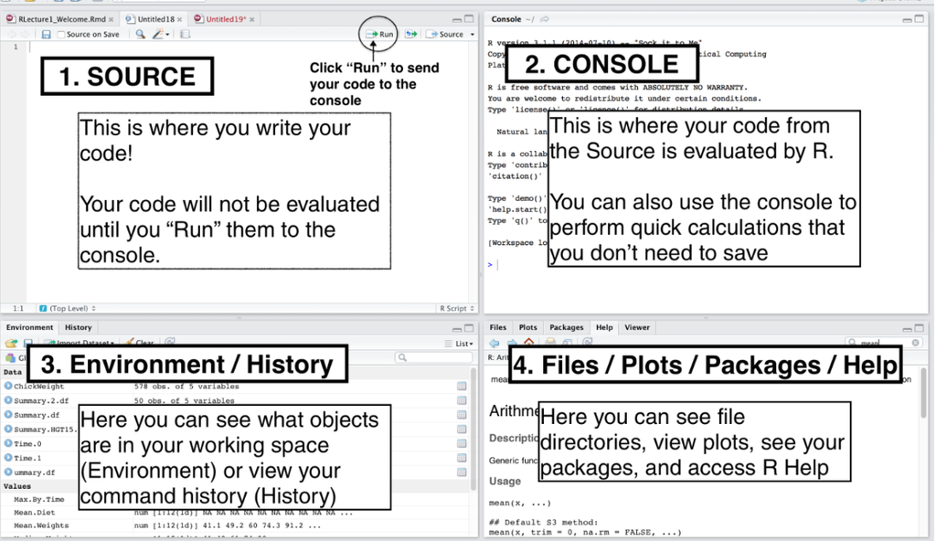

# Working in RStudio/RStudio Cloud

### R Script

- A R script is a .R file that contains R code.
- To create a R script, go to **File > New > R Script**, or click the green-plus icon on the top left corner, and select R Script.

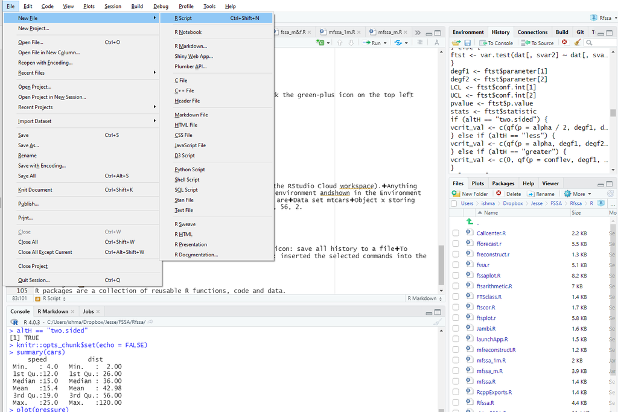

# Working in RStudio/RStudio Cloud

### Run Code

- Run: run the current line or selection of code.
  - **ctrl + enter** (Windows) or **cmd + enter** (Mac)
- Icon right to the Run: re-run the previous selected code.
  - **shift + ctrl + p** (Windows) or **shift + cmd + enter** (Mac)
- Source: run all the code in the R script.

# Environment Tab

# History Tab

- The History tab keeps a record of all previous commands.
- save icon: save all history to a file
- To Console: send the selected commands to the R console.
- To Source: inserted the selected commands into the current R script.

# R Packages

- R packages are a collection of reusable R functions, code and data.
- When we start a R session, only built-in packages like **base, stats**, etc are available.
- Installing a package is an easy way to access to others data and functions.

[figure not shown]

  ### Installing R Packages
- To install a package, for example, the **ggplot2** package, we use the command

```
install.packages("ggplot2")
```